# 02_time_step_sensitivity

Madelyne Zhang

2026-01-15

## Overview

The goal of this analysis is to check how the choice of time step affects the fitted movement tracks and persistence estimates. We do this by refitting the models for a small number of sharks using different time step specifications.

```r
library(tidyverse)
library(lubridate)
library(sf)
library(aniMotum)
sharks_ssm_clean <- readRDS("sharks_ssm_clean.rds")
```

## Sensitivity analysis design

### Individual 1: sparse-observation case (ID = 139119)

```r
# Select the shark that has unusual high persistence for time-step sensitivity analysis
sens_id1 <- "139119"

shark_dat <- sharks_ssm_clean %>%
  filter(id == sens_id1)
```

### State-space model fitting under different time steps

```r
# Three SSM with different time steps
ssm_24 <- fit_ssm(
  x = shark_dat,
  model = "crw",
  time.step = 24,
  vmax = 2.7,
  control = ssm_control(verbose = 0)
)
```

```r
ssm_48 <- fit_ssm(
  x = shark_dat,
  model = "crw",
  time.step = 48,
  vmax = 2.7,
  control = ssm_control(verbose = 0)
)
```

```r
ssm_na <- fit_ssm(
  x = shark_dat,
  model = "crw",
  time.step = NA,
  vmax = 2.7,
  control = ssm_control(verbose = 0)
)
```

```r
ssm_24
```

```
## # A tibble: 1 × 5
##   id     ssm          converged pdHess pmodel
##   <chr>  <named list> <lgl>     <lgl>  <chr>
## 1 139119 <ssm [15]>   TRUE      TRUE   crw
```

```r
ssm_48
```

```
## # A tibble: 1 × 5
##   id     ssm          converged pdHess pmodel
##   <chr>  <named list> <lgl>     <lgl>  <chr>
## 1 139119 <ssm [15]>   TRUE      TRUE   crw
```

```r
ssm_na
```

```
## # A tibble: 1 × 5
##   id     ssm          converged pdHess pmodel
##   <chr>  <named list> <lgl>     <lgl>  <chr>
## 1 139119 <ssm [15]>   TRUE      TRUE   crw
```

The three models with different time steps all converged.

#### Comparison of fitted locations

```r
# Extract fitted locations (at observation times)
fitted_24 <- grab(ssm_24, what = "fitted") %>%
  as_tibble() %>%
  mutate(model = "24h")

fitted_48 <- grab(ssm_48, what = "fitted") %>%
  as_tibble() %>%
  mutate(model = "48h")

fitted_na <- grab(ssm_na, what = "fitted") %>%
  as_tibble() %>%
  mutate(model = "NA")
```

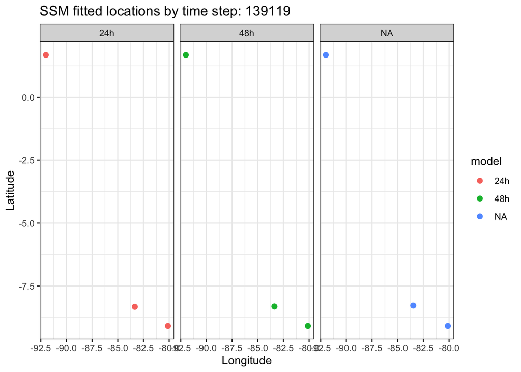

```r
bind_rows(fitted_24, fitted_48, fitted_na) %>%
  ggplot(aes(x = lon, y = lat, colour = model)) +
  geom_point(size = 2) +
  facet_wrap(~ model) +
  theme_bw() +
  labs(
    title = paste("SSM fitted locations by time step:", sens_id1),
    x = "Longitude",
    y = "Latitude"
  )
```

For this individual, the fitted latent locations were very similar across time.step = 24, 48, and NA, indicating that the SSM reconstruction is not sensitive to the choice of time step.

### Move persistence model fitting

```r
# Three MPM models
pred_24 <- grab(ssm_24, what = "predicted") %>%
  as_tibble() %>%
  mutate(model = "24h")

pred_48 <- grab(ssm_48, what = "predicted") %>%
  as_tibble() %>%
  mutate(model = "48h")

pred_na <- grab(ssm_na, what = "fitted") %>%
  as_tibble() %>%
  mutate(model = "NA")
```

```r
mpm_24 <- fit_mpm(
  pred_24,
  model = "mpm",
  control = mpm_control(verbose = 0)
)
```

```r
mpm_48 <- fit_mpm(
  pred_48,
  model = "mpm",
  control = mpm_control(verbose = 0)
)
mpm_na <- fit_mpm(
  pred_na,
  model = "mpm",
  control = mpm_control(verbose = 0)
)
g_24 <- grab(mpm_24, what = "fitted") %>%
  as_tibble() %>%
  mutate(model = "24h")

g_48 <- grab(mpm_48, what = "fitted") %>%
  as_tibble() %>%
  mutate(model = "48h")

g_na <- grab(mpm_na, what = "fitted") %>%
  as_tibble() %>%
  mutate(model = "NA")
```

#### Sensitivity of move persistence estimates

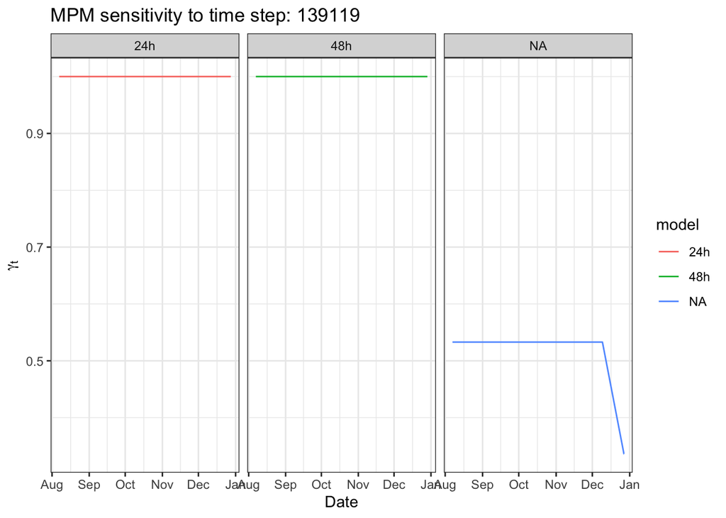

```r
bind_rows(g_24, g_48, g_na) %>%
  ggplot(aes(x = date, y = g, colour = model)) +
  geom_line() +
  facet_wrap(~ model, scales = "free_x") +
  theme_bw() +
  labs(
    title = paste("MPM sensitivity to time step:", sens_id1),
    x = "Date",
    y = expression(gamma[t])
  )
```

Movement persistence estimates were highly consistent between 24 h and 48 h regularization, whereas estimates based on irregular observation times (time.step = NA) showed markedly different behaviour, supporting the use of regularized predicted locations for MPM inference.

### Shark track visualization on different time steps

```r
# 24h
df_locs_24 <- ssm_24 %>% grab("predicted")
df_mpm_24  <- mpm_24 %>% grab("fitted")

df_24 <- df_locs_24 %>%
  left_join(df_mpm_24, by = c("id", "date")) %>%
  mutate(model = "24h")

# 48h
df_locs_48 <- ssm_48 %>% grab("predicted")
df_mpm_48  <- mpm_48 %>% grab("fitted")

df_48 <- df_locs_48 %>%
  left_join(df_mpm_48, by = c("id", "date")) %>%
  mutate(model = "48h")

# NA Since NA doesn't have predicted, so we visualize it using fitted
df_locs_na <- ssm_na %>% grab("fitted")
df_mpm_na  <- mpm_na %>% grab("fitted")

df_na <- df_locs_na %>%
  left_join(df_mpm_na, by = c("id", "date")) %>%
  mutate(model = "NA")
```

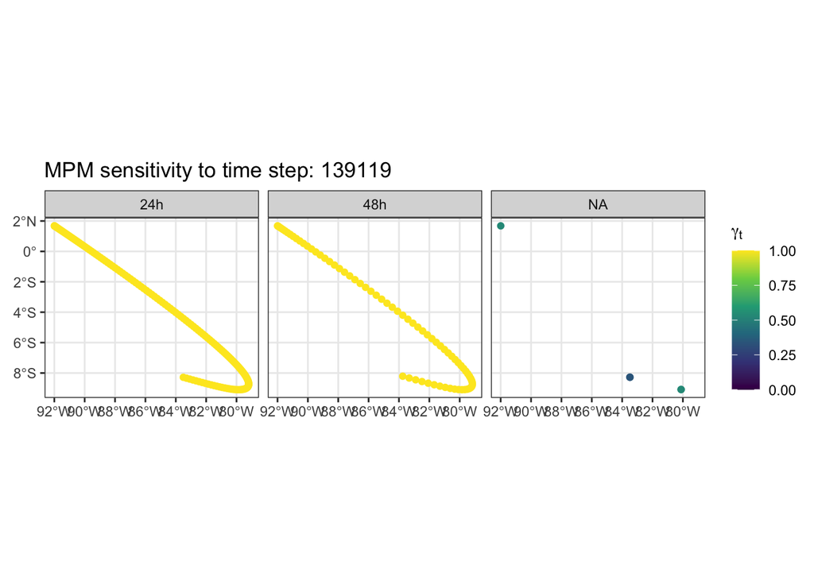

```r
df_all <- bind_rows(df_24, df_48, df_na)

# Transform to sf
df_sf <- df_all %>%
  st_as_sf(coords = c("lon", "lat")) %>%
  st_set_crs(4326)

# ggplot
p_ts1 <- ggplot() +
  theme_bw() +
  geom_sf(aes(colour = g), data = df_sf, show.legend = "point") +
  scale_color_viridis_c(expression(gamma[t]), limits = c(0, 1)) +
  facet_wrap(~ model, nrow = 1) +
  labs(
    title = paste("MPM sensitivity to time step:", sens_id1)
  )

print(p_ts1)
```

```r
# Save Plot
ggsave(
  filename = "g_spatial_timestep_comparison1.png",
  plot = p_ts1,
  width = 9,
  height = 4,
  dpi = 300
)
```

### Individual 2: Highly variable gamma shark case (ID = 220359)

```r
# Select the shark with highly variable movement persistence
sens_id2 <- "220359"

shark_dat_2 <- sharks_ssm_clean %>%
  filter(id == sens_id2)
```

### State-space model fitting under different time steps

```r
# Three SSM with different time steps
ssm2_24 <- fit_ssm(
  x = shark_dat_2,
  model = "crw",
  time.step = 24,
  vmax = 2.7,
  control = ssm_control(verbose = 0)
)
```

```r
ssm2_48 <- fit_ssm(
  x = shark_dat_2,
  model = "crw",
  time.step = 48,
  vmax = 2.7,
  control = ssm_control(verbose = 0)
)
```

```r
ssm2_na <- fit_ssm(
  x = shark_dat_2,
  model = "crw",
  time.step = NA,
  vmax = 2.7,
  control = ssm_control(verbose = 0)
)
```

```r
ssm2_24
```

```
## # A tibble: 1 × 5
##   id     ssm          converged pdHess pmodel
##   <chr>  <named list> <lgl>     <lgl>  <chr>
## 1 220359 <ssm [15]>   TRUE      TRUE   crw
```

```r
ssm2_48
```

```
## # A tibble: 1 × 5
##   id     ssm          converged pdHess pmodel
##   <chr>  <named list> <lgl>     <lgl>  <chr>
## 1 220359 <ssm [15]>   TRUE      TRUE   crw
```

```r
ssm2_na
```

```
## # A tibble: 1 × 5
##   id     ssm          converged pdHess pmodel
##   <chr>  <named list> <lgl>     <lgl>  <chr>
## 1 220359 <ssm [15]>   TRUE      TRUE   crw
```

The three models with different time steps all converged.

#### Comparison of fitted locations

```r
# Extract fitted locations (at observation times)
fitted2_24 <- grab(ssm2_24, what = "fitted") %>%
  as_tibble() %>%
  mutate(model = "24h")

fitted2_48 <- grab(ssm2_48, what = "fitted") %>%
  as_tibble() %>%
  mutate(model = "48h")

fitted2_na <- grab(ssm2_na, what = "fitted") %>%
  as_tibble() %>%
  mutate(model = "NA")
```

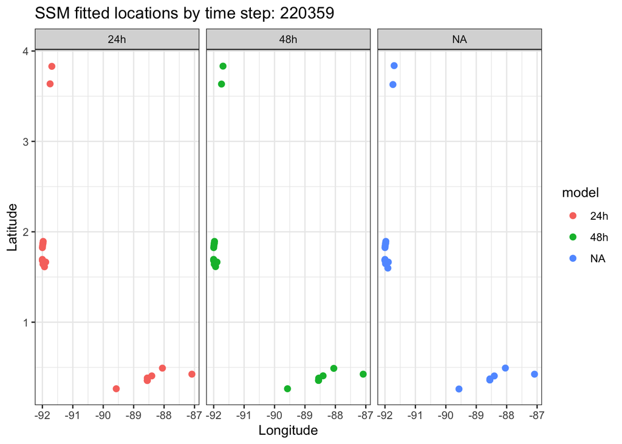

```r
bind_rows(fitted2_24, fitted2_48, fitted2_na) %>%
  ggplot(aes(x = lon, y = lat, colour = model)) +
  geom_point(size = 2) +
  facet_wrap(~ model) +
  theme_bw() +
  labs(
    title = paste("SSM fitted locations by time step:", sens_id2),
    x = "Longitude",
    y = "Latitude"
  )
```

For this individual, the fitted latent locations were very similar across time.step = 24, 48, and NA, indicating that the SSM reconstruction is not sensitive to the choice of time step.

### Move persistence model fitting

```r
# Three MPM models
pred2_24 <- grab(ssm2_24, what = "predicted") %>%
  as_tibble() %>%
  mutate(model = "24h")

pred2_48 <- grab(ssm2_48, what = "predicted") %>%
  as_tibble() %>%
  mutate(model = "48h")

pred2_na <- grab(ssm2_na, what = "fitted") %>%
  as_tibble() %>%
  mutate(model = "NA")
```

```r
mpm2_24 <- fit_mpm(
  pred2_24,
  model = "mpm",
  control = mpm_control(verbose = 0)
)
```

```r
mpm2_48 <- fit_mpm(
  pred2_48,
  model = "mpm",
  control = mpm_control(verbose = 0)
)
```

```r
mpm2_na <- fit_mpm(
  pred2_na,
  model = "mpm",
  control = mpm_control(verbose = 0)
)
```

```r
g2_24 <- grab(mpm2_24, what = "fitted") %>%
  as_tibble() %>%
  mutate(model = "24h")

g2_48 <- grab(mpm2_48, what = "fitted") %>%
  as_tibble() %>%
  mutate(model = "48h")

g2_na <- grab(mpm2_na, what = "fitted") %>%
  as_tibble() %>%
  mutate(model = "NA")
```

#### Sensitivity of move persistence estimates

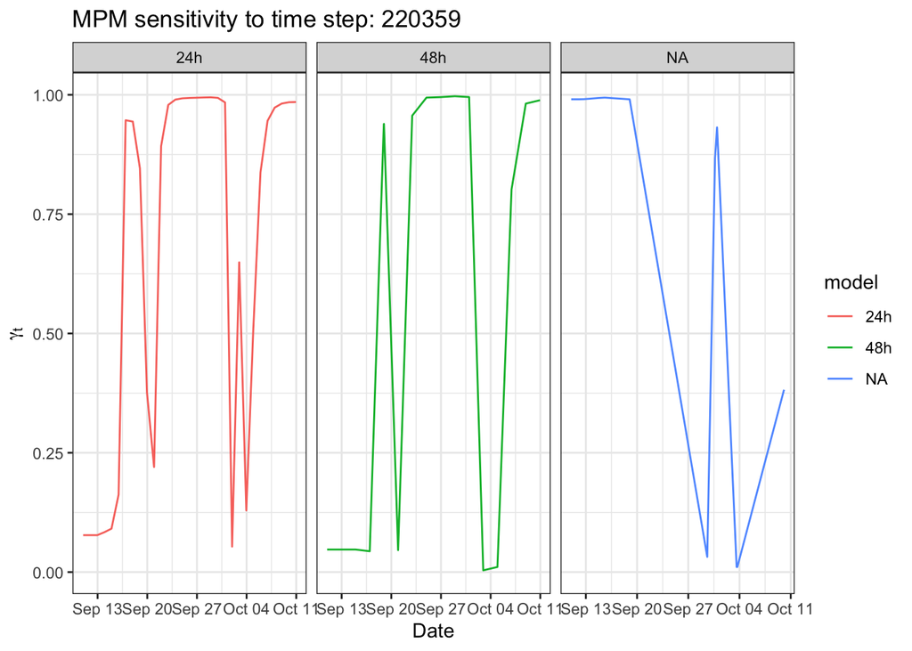

```r
bind_rows(g2_24, g2_48, g2_na) %>%
  ggplot(aes(x = date, y = g, colour = model)) +
  geom_line() +
  facet_wrap(~ model, scales = "free_x") +
  theme_bw() +
  labs(
    title = paste("MPM sensitivity to time step:", sens_id2),
    x = "Date",
    y = expression(gamma[t])
  )
```

For shark 220359, γₜ varies substantially over time under both 24 h and 48 h regulaization, with similar timing of transitions between low and high persistence. In contrast, estimates based on time.step = NA rely on a small number of irregular observation times and show abrupt changes driven by individual observations.

### Shark track visualization on different time steps

```r
# 24h
df2_locs_24 <- ssm2_24 %>% grab("predicted")
df2_mpm_24  <- mpm2_24 %>% grab("fitted")

df2_24 <- df2_locs_24 %>%
  left_join(df2_mpm_24, by = c("id", "date")) %>%
  mutate(model = "24h")

# 48h
df2_locs_48 <- ssm2_48 %>% grab("predicted")
df2_mpm_48  <- mpm2_48 %>% grab("fitted")

df2_48 <- df2_locs_48 %>%
  left_join(df2_mpm_48, by = c("id", "date")) %>%
  mutate(model = "48h")

# NA Since NA doesn't have predicted, so we visualize it using fitted
df2_locs_na <- ssm2_na %>% grab("fitted")
df2_mpm_na  <- mpm2_na %>% grab("fitted")

df2_na <- df2_locs_na %>%
  left_join(df2_mpm_na, by = c("id", "date")) %>%
  mutate(model = "NA")
```

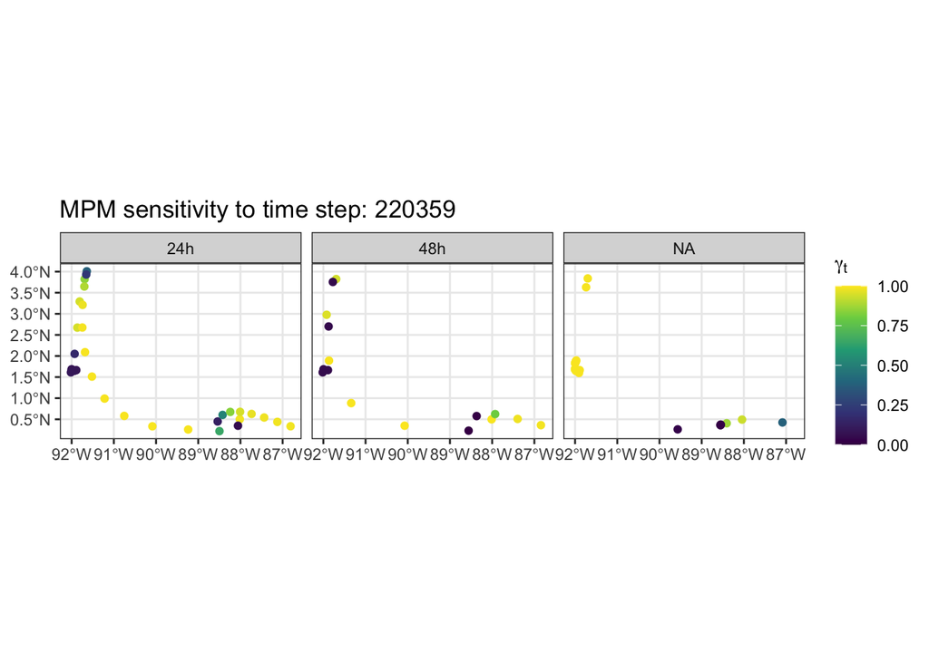

```r
df2_all <- bind_rows(df2_24, df2_48, df2_na)

# Transform to sf
df2_sf <- df2_all %>%
  st_as_sf(coords = c("lon", "lat")) %>%
  st_set_crs(4326)

# ggplot
p_ts2 <- ggplot() +
  theme_bw() +
  geom_sf(aes(colour = g), data = df2_sf, show.legend = "point") +
  scale_color_viridis_c(expression(gamma[t]), limits = c(0, 1)) +
  facet_wrap(~ model, nrow = 1) +
  labs(
    title = paste("MPM sensitivity to time step:", sens_id2)
  )

print(p_ts2)
```

```r
# Save figures to folder
ggsave(
  filename = "g_spatial_timestep_comparison2.png",
  plot = p_ts2,
  width = 9,
  height = 4,
  dpi = 300
)
```

The 24 h and 48 h regularisations yield comparable overall movement patterns but differ in the spatial resolution of γₜ, with stronger temporal aggregation under the 48 h time step. The NA case is restricted by the small number of observed locations.

### Individual 3: Typical gamma shark case (ID = 184025)

```r
# Select the shark with typical movement persistence
sens_id3 <- "184025"

shark_dat_3 <- sharks_ssm_clean %>%
  filter(id == sens_id3)
```

### State-space model fitting under different time steps

```r
# Three SSM with different time steps
ssm3_24 <- fit_ssm(
  x = shark_dat_3,
  model = "crw",
  time.step = 24,
  vmax = 2.7,
  control = ssm_control(verbose = 0)
)
```

```r
ssm3_48 <- fit_ssm(
  x = shark_dat_3,
  model = "crw",
  time.step = 48,
  vmax = 2.7,
  control = ssm_control(verbose = 0)
)
```

```r
ssm3_na <- fit_ssm(
  x = shark_dat_3,
  model = "crw",
  time.step = NA,
  vmax = 2.7,
  control = ssm_control(verbose = 0)
)
```

```r
ssm3_24
```

```
## # A tibble: 1 × 5
##   id     ssm          converged pdHess pmodel
##   <chr>  <named list> <lgl>     <lgl>  <chr>
## 1 184025 <ssm [15]>   TRUE      TRUE   crw
```

```r
ssm3_48
```

```
## # A tibble: 1 × 5
##   id     ssm          converged pdHess pmodel
##   <chr>  <named list> <lgl>     <lgl>  <chr>
## 1 184025 <ssm [15]>   TRUE      TRUE   crw
```

```r
ssm3_na
```

```
## # A tibble: 1 × 5
##   id     ssm          converged pdHess pmodel
##   <chr>  <named list> <lgl>     <lgl>  <chr>
## 1 184025 <ssm [15]>   TRUE      TRUE   crw
```

The three models with different time steps all converged.

#### Comparison of fitted locations

```r
# Extract fitted locations (at observation times)
fitted3_24 <- grab(ssm3_24, what = "fitted") %>%
  as_tibble() %>%
  mutate(model = "24h")

fitted3_48 <- grab(ssm3_48, what = "fitted") %>%
  as_tibble() %>%
  mutate(model = "48h")

fitted3_na <- grab(ssm3_na, what = "fitted") %>%
  as_tibble() %>%
  mutate(model = "NA")
```

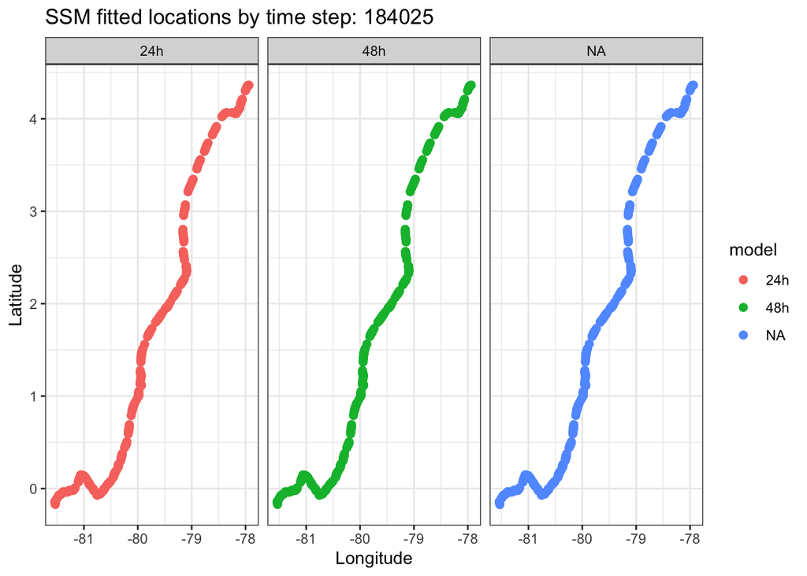

```r
bind_rows(fitted3_24, fitted3_48, fitted3_na) %>%
  ggplot(aes(x = lon, y = lat, colour = model)) +
  geom_point(size = 2) +
  facet_wrap(~ model) +
  theme_bw() +
  labs(
    title = paste("SSM fitted locations by time step:", sens_id3),
    x = "Longitude",
    y = "Latitude"
  )
```

For this individual, the fitted latent locations were very similar across time.step = 24, 48, and NA, indicating that the SSM reconstruction is not sensitive to the choice of time step.

### Move persistence model fitting

```r
# Three MPM models
pred3_24 <- grab(ssm3_24, what = "predicted") %>%
  as_tibble() %>%
  mutate(model = "24h")

pred3_48 <- grab(ssm3_48, what = "predicted") %>%
  as_tibble() %>%
  mutate(model = "48h")

pred3_na <- grab(ssm3_na, what = "fitted") %>%
  as_tibble() %>%
  mutate(model = "NA")
```

```r
mpm3_24 <- fit_mpm(
  pred3_24,
  model = "mpm",
  control = mpm_control(verbose = 0)
)
```

```r
mpm3_48 <- fit_mpm(
  pred3_48,
  model = "mpm",
  control = mpm_control(verbose = 0)
)
```

```r
mpm3_na <- fit_mpm(
  pred3_na,
  model = "mpm",
  control = mpm_control(verbose = 0)
)
```

```r
g3_24 <- grab(mpm3_24, what = "fitted") %>%
  as_tibble() %>%
  mutate(model = "24h")

g3_48 <- grab(mpm3_48, what = "fitted") %>%
  as_tibble() %>%
  mutate(model = "48h")

g3_na <- grab(mpm3_na, what = "fitted") %>%
  as_tibble() %>%
  mutate(model = "NA")
```

#### Sensitivity of move persistence estimates

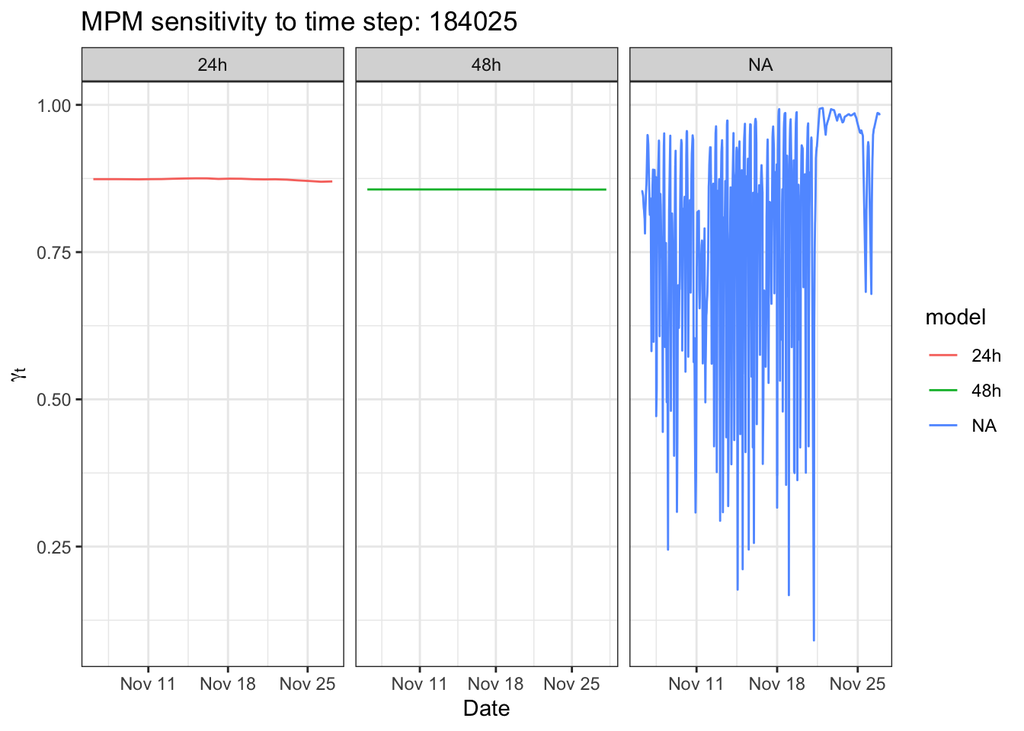

```r
bind_rows(g3_24, g3_48, g3_na) %>%
  ggplot(aes(x = date, y = g, colour = model)) +
  geom_line() +
  facet_wrap(~ model, scales = "free_x") +
  theme_bw() +
  labs(
    title = paste("MPM sensitivity to time step:", sens_id3),
    x = "Date",
    y = expression(gamma[t])
  )
```

For this individual, γₜ estimates are stable and highly similar under 24 h and 48 h regularization. Estimates based on irregular observation times exhibit markedly higher short-term variability.

### Shark track visualization on different time steps

```r
# 24h
df3_locs_24 <- ssm3_24 %>% grab("predicted")
df3_mpm_24  <- mpm3_24 %>% grab("fitted")

df3_24 <- df3_locs_24 %>%
  left_join(df3_mpm_24, by = c("id", "date")) %>%
  mutate(model = "24h")

# 48h
df3_locs_48 <- ssm3_48 %>% grab("predicted")
df3_mpm_48  <- mpm3_48 %>% grab("fitted")

df3_48 <- df3_locs_48 %>%
  left_join(df3_mpm_48, by = c("id", "date")) %>%
  mutate(model = "48h")

# NA Since NA doesn't have predicted, so we visualize it using fitted
df3_locs_na <- ssm3_na %>% grab("fitted")
df3_mpm_na  <- mpm3_na %>% grab("fitted")

df3_na <- df3_locs_na %>%
  left_join(df3_mpm_na, by = c("id", "date")) %>%
  mutate(model = "NA")
```

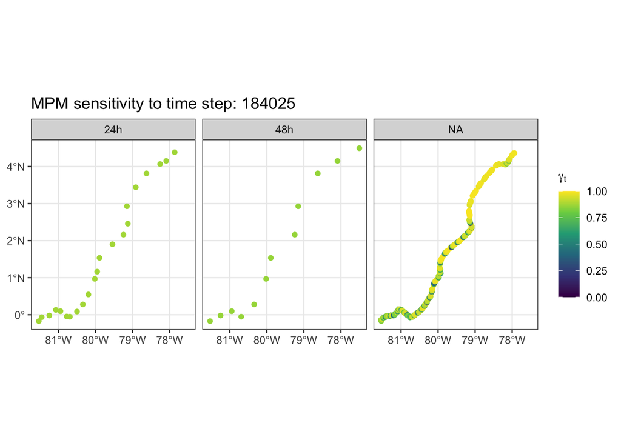

```r
df3_all <- bind_rows(df3_24, df3_48, df3_na)

# Transform to sf
df3_sf <- df3_all %>%
  st_as_sf(coords = c("lon", "lat")) %>%
  st_set_crs(4326)

# ggplot
p_ts3 <- ggplot() +
  theme_bw() +
  geom_sf(aes(colour = g), data = df3_sf, show.legend = "point") +
  scale_color_viridis_c(expression(gamma[t]), limits = c(0, 1)) +
  facet_wrap(~ model, nrow = 1) +
  labs(
    title = paste("MPM sensitivity to time step:", sens_id3)
  )

print(p_ts3)
```

```r
# Save figures to folder
ggsave(
  filename = "g_spatial_timestep_comparison3.png",
  plot = p_ts3,
  width = 9,
  height = 4,
  dpi = 300
)
```